# Exploratory Data Visualization with the Artist Class

[cw](https://cying.org)

2026-10-07

## Introduction

The `Artist` class provides a fluent interface for rapid exploratory data visualization using `ggplot2`. It is designed to let you iterate quickly: plot, test, re-plot, and review your entire exploration history.

Key features:

- **Method chaining**: all methods return `invisible(self)`, enabling a fluid workflow
- **Automatic annotations**: `plot_*` methods detect prior statistical tests and add results as plot titles
- **Command history**: every method call is recorded in `$command` and `$result`
- **In-place data transformation**: the `fun` parameter lets you modify `self$data` on the fly

## Setup

```r
litedown::reactor(warning = FALSE)

library(easybio)
library(data.table)
```

```r
# Example data: airquality, focusing on May and June
air <- subset(airquality, Month %in% c(5, 6))
setDT(air)
```

## Basic Usage

Create an `Artist` instance and start plotting.

```r
a <- Artist$new(data = air)
```

```
#> Welcome to the amazing Artist's world, enjoy exploring your data in a new way!
```

```r
a$plot_scatter(x = Wind, y = Temp)
```

[output not shown]

The plot is displayed immediately and stored in `a$result`. You can retrieve the full history at any time:

```r
a$get_all_result()[, .(command)]
```

| command |
| --- |
| <call[3]> |

## Statistical Tests and Auto-Annotation

This is the core design of Artist. When a `plot_*` method follows a `test_*` method, the statistical result is automatically added to the plot title.

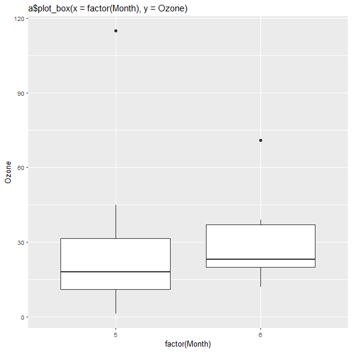

```r
a$plot_box(x = factor(Month), y = Ozone)
```

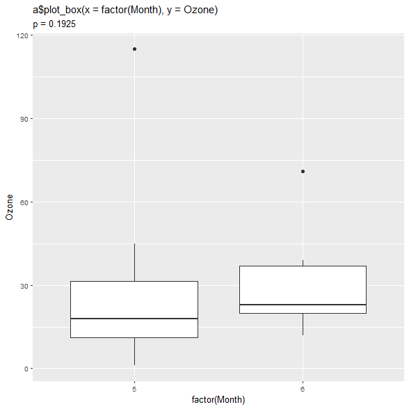

```r
a$test_wilcox(formula = Ozone ~ Month)
a$plot_box(x = factor(Month), y = Ozone)
```

Notice how the second `plot_box` includes the previous test in its title — you immediately see the comparison context.

The same works with `t.test`:

```r
a$plot_scatter(x = Wind, y = Temp)
```

[output not shown]

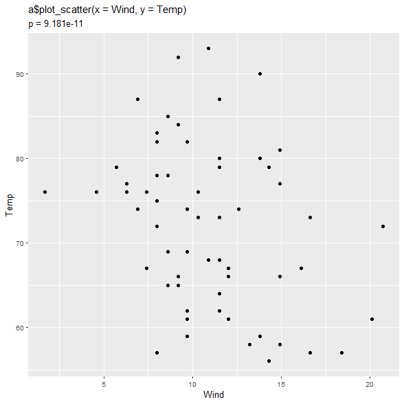

```r
a$test_t(formula = Temp ~ Month)
a$plot_scatter(x = Wind, y = Temp)
```

## Method Chaining

All methods return the Artist object itself, so you can chain calls:

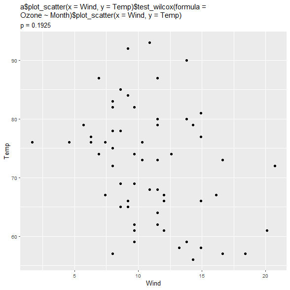

```r
a$plot_scatter(x = Wind, y = Temp)$
  test_wilcox(formula = Ozone ~ Month)$
  plot_scatter(x = Wind, y = Temp)
```

## Data Transformation with `fun`

The `fun` parameter applies a transformation to `self$data` before plotting. This is useful for derived variables:

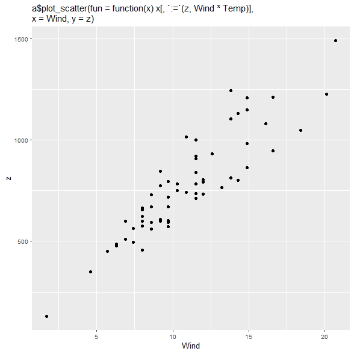

```r
a$plot_scatter(
  fun = \(x) x[, z := Wind * Temp],
  x = Wind,
  y = z
)
```

The transformation is applied in-place, so `a$data` now contains the `z` column.

## Available Plot Types

All plot methods follow the same interface and support chaining.

### Dumbbell Plot

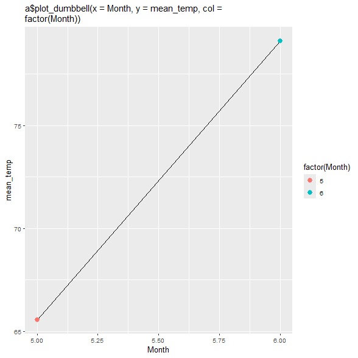

```r
# Summarise data for dumbbell
air[, mean_temp := mean(Temp), by = Month]
a$plot_dumbbell(x = Month, y = mean_temp, col = factor(Month))
```

### Bubble Plot

```r
air[, .N, by = .(Month, Day)]
```

| Month | Day | N |
| --- | --- | --- |
| 5 | 1 | 1 |
| 5 | 2 | 1 |
| 5 | 3 | 1 |
| 5 | 4 | 1 |
| 5 | 5 | 1 |
| ⋮ | ⋮ | ⋮ |
| 6 | 26 | 1 |
| 6 | 27 | 1 |
| 6 | 28 | 1 |
| 6 | 29 | 1 |
| 6 | 30 | 1 |

```r
a2 <- Artist$new(data = air[, .N, by = .(Month, Day)])
```

```
#> Welcome to the amazing Artist's world, enjoy exploring your data in a new way!
```

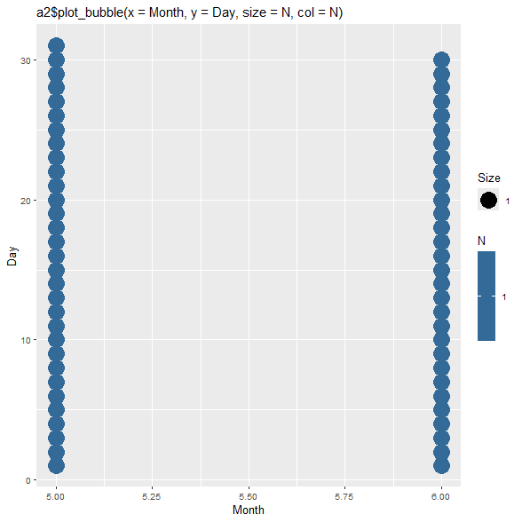

```r
a2$plot_bubble(x = Month, y = Day, size = N, col = N)
```

### Divergence Bar Chart

```r
# Create some example data with positive and negative values
example <- data.table(
  group = letters[1:6],
  value = c(1.5, -0.8, 2.1, -1.2, 0.5, -0.3)
)
a3 <- Artist$new(data = example)
```

```
#> Welcome to the amazing Artist's world, enjoy exploring your data in a new way!
```

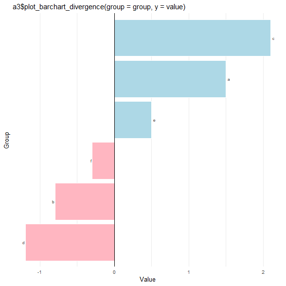

```r
a3$plot_barchart_divergence(group = group, y = value)
```

### Lollipop Plot

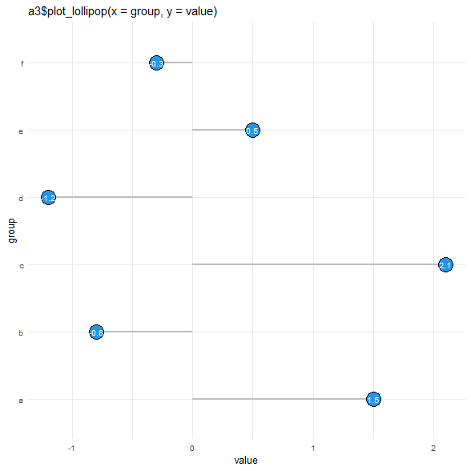

```r
a3$plot_lollipop(x = group, y = value)
```

### Contour Plot

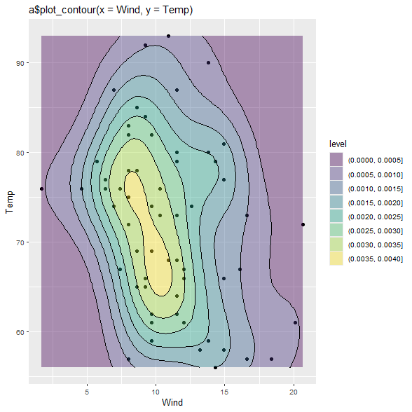

```r
a$plot_contour(x = Wind, y = Temp)
```

### Scatter Plot with Ellipses

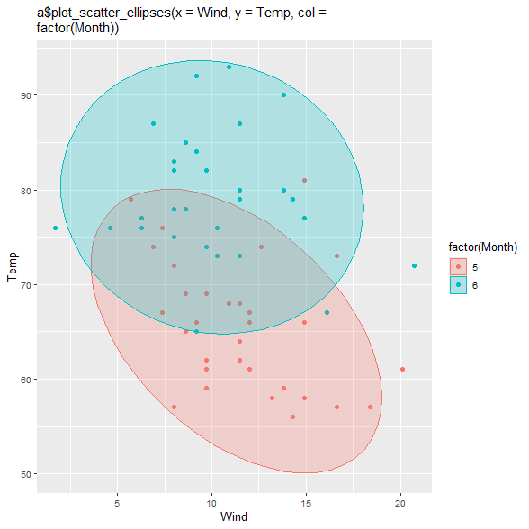

```r
a$plot_scatter_ellipses(x = Wind, y = Temp, col = factor(Month))
```

### Donut Plot

```r
month_counts <- air[, .N, by = Month]
a4 <- Artist$new(data = month_counts)
```

```
#> Welcome to the amazing Artist's world, enjoy exploring your data in a new way!
```

[figure not shown]

```r
a4$plot_donut(x = Month, y = N, fill = factor(Month))
```

### Pie Chart

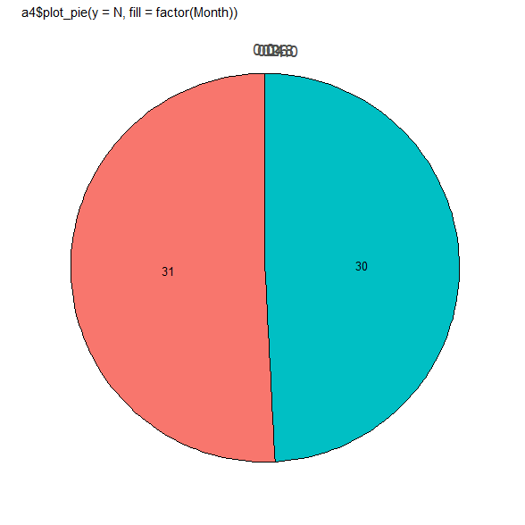

```r
a4$plot_pie(y = N, fill = factor(Month))
```

## Reviewing Your Exploration History

Every plot and test is recorded. Use `get_all_result()` to see the full log:

```r
history <- a$get_all_result()
history
```

| command | result |
| --- | --- |
| <call[3]> | <gg[11]> |
| <call[3]> | <gg[11]> |
| <call[2]> | <htest[7]> |
| <call[3]> | <gg[11]> |
| <call[3]> | <gg[11]> |
| ⋮ | ⋮ |
| <call[3]> | <gg[11]> |
| <call[4]> | <gg[11]> |
| <call[4]> | <gg[11]> |
| <call[3]> | <gg[11]> |
| <call[4]> | <gg[11]> |

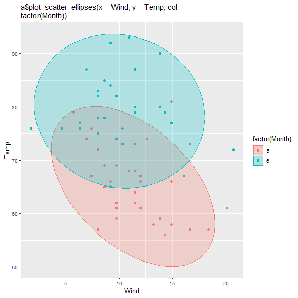

```r
# The last plot
a$result[[length(a$result)]]
```

```r
# The last statistical test result
for (res in a$result) {
  if (inherits(res, "htest")) print(res)
}
```

```
#>
#> 	Wilcoxon rank sum test with continuity correction
#>
#> data:  Ozone by Month
#> W = 82, p-value = 0.1925
#> alternative hypothesis: true location shift is not equal to 0
#>
#>
#> 	Welch Two Sample t-test
#>
#> data:  Temp by Month
#> t = -7.8672, df = 58.999, p-value = 9.181e-11
#> alternative hypothesis: true difference in means between group 5 and group 6 is not equal to 0
#> 95 percent confidence interval:
#>  -16.99842 -10.10481
#> sample estimates:
#> mean in group 5 mean in group 6
#>        65.54839        79.10000
#>
#>
#> 	Wilcoxon rank sum test with continuity correction
#>
#> data:  Ozone by Month
#> W = 82, p-value = 0.1925
#> alternative hypothesis: true location shift is not equal to 0
#>
```

## Summary

The `Artist` class turns exploratory data analysis into a structured, reproducible workflow. You can:

1. **Plot** → `plot_scatter`, `plot_box`, `plot_dumbbell`, etc.
2. **Test** → `test_wilcox`, `test_t`
3. **Re-plot** → same plot method now shows test context
4. **Review** → `get_all_result()` gives you the complete history

This makes it ideal for quick data inspection before committing to a formal analysis pipeline.